# Motor Trend Car Road Tests - Effects of transmission on MPG

Tanguy Levent

8 mars 2017

Github account for the scripts : https://github.com/TanguyLevent

# Synopsis

The data was extracted from the 1974 Motor Trend US magazine, and comprises fuel consumption and 10 aspects of automobile design and performance for 32 automobiles (1973–74 models). We are going to analyze and select the predictors of our dataset by AIC method (Akaike Information Criterion) to regressing the fuel consumption - unit *miles per gallon (MPG)*.

The questions of our researches are :

- Is an automatic or manual transmission better for MPG?
- Quantifying how different is the MPG between automatic and manual transmissions?

# Data Processing

Please install the R package **PerformanceAnalytics** if you don’t have it : `install.packages("PerformanceAnalytics")`. Then call `mtcars` dataset, verify there are no missing values and compute simply summaries to have an idea of the variables inside.

```r
library(dplyr)
library(PerformanceAnalytics)

data("mtcars")
sum(is.na(mtcars))
```

```
## [1] 0
```

```r
head(mtcars)
```

```
##                    mpg cyl disp  hp drat    wt  qsec vs am gear carb
## Mazda RX4         21.0   6  160 110 3.90 2.620 16.46  0  1    4    4
## Mazda RX4 Wag     21.0   6  160 110 3.90 2.875 17.02  0  1    4    4
## Datsun 710        22.8   4  108  93 3.85 2.320 18.61  1  1    4    1
## Hornet 4 Drive    21.4   6  258 110 3.08 3.215 19.44  1  0    3    1
## Hornet Sportabout 18.7   8  360 175 3.15 3.440 17.02  0  0    3    2
## Valiant           18.1   6  225 105 2.76 3.460 20.22  1  0    3    1
```

```r
str(mtcars)
```

```
## 'data.frame':    32 obs. of  11 variables:
##  $ mpg : num  21 21 22.8 21.4 18.7 18.1 14.3 24.4 22.8 19.2 ...
##  $ cyl : num  6 6 4 6 8 6 8 4 4 6 ...
##  $ disp: num  160 160 108 258 360 ...
##  $ hp  : num  110 110 93 110 175 105 245 62 95 123 ...
##  $ drat: num  3.9 3.9 3.85 3.08 3.15 2.76 3.21 3.69 3.92 3.92 ...
##  $ wt  : num  2.62 2.88 2.32 3.21 3.44 ...
##  $ qsec: num  16.5 17 18.6 19.4 17 ...
##  $ vs  : num  0 0 1 1 0 1 0 1 1 1 ...
##  $ am  : num  1 1 1 0 0 0 0 0 0 0 ...
##  $ gear: num  4 4 4 3 3 3 3 4 4 4 ...
##  $ carb: num  4 4 1 1 2 1 4 2 2 4 ...
```

Looking at the data, we find our 10 automobile performances for 32 automobiles.  
Please find the explanation of the variables on the original documentation website: https://stat.ethz.ch/R-manual/R-devel/library/datasets/html/mtcars.html

# Exploratory analysis

First I used to plot a chart correlation in order to have a general view of our variables and the link they have with each other.

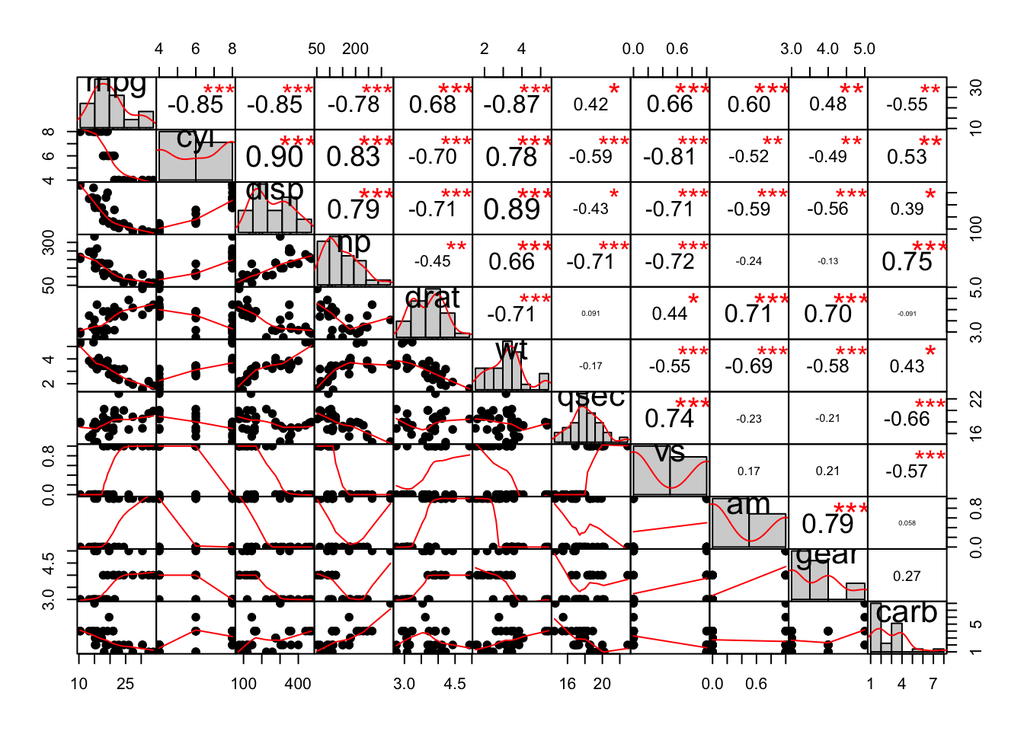

Conspicuously there are variables which are related with the response `mpg` :

- `cyl` which is in fact a factor variable
- `disp`
- `hp`
- `drat`
- `wt`
- `vs` which is in fact a factor variable
- `am` which is in fact a factor variable

To finish this part, we arrange our dataset with all the informations that we have processing before.

```r
mdata <- mtcars %>% select(mpg,cyl,disp,hp,drat,wt,vs,am)
mdata$cyl <- factor(mdata$cyl)
mdata$vs <- factor(mdata$vs)
mdata$am = factor(mdata$am, labels = c("Automatic","Manual"))
```

# Statistical inference

The purpose of our analyze is to focus on the relationship between mpg and am. The first way to look at it is to perform a hypothesis test by test the *null hypothesis* :

1. $H_0$ : There is no relationship between MPG and the transmission (am)

versus the *alternative hypothesis* :

2. $H_\alpha$ : There is some relationship between MPG and the transmission (am)

Below the computation of the *t-statistic* and his associate result :

```r
test$p.value
```

[output not shown]

```
## [1] 0.001373638
```

```r
test$estimate
```

```
## mean in group Automatic    mean in group Manual
##                17.14737                24.39231
```

# Regression linear

Once we have rejected the null hypothesis in favor of the alternative hypothesis, it is natural to want to quantify *the extent to which the model fits the data* with the Residual Standard Error (RSE ou $\epsilon$) which is a measure of the *lack of fit* the model but it not always clear what constitutes a good RSE so $R^2$ statistics provides an alternative measure of fit. It takes the form of a *proportion* - the proportion of variability that can be explained using $X$. A number near 0 indicates that the regression did not explain much of the variability in the response.

Mathematically the linear relationship can be write as :
$$MPG \approx \beta_0 + \beta_1 \times am + \epsilon$$
where $\epsilon$ is the error term. Let’s write the linear regression r code :

```r
mpg.lm.am <- lm(mpg ~ am, mdata)
```

that gives us for the RSE and $R^2$ :

```r
round(sigma(mpg.lm.am),2)
```

```
## [1] 4.9
```

```r
round(summary(mpg.lm.am)$adj.r.squared,3)
```

```
## [1] 0.338
```

In other words, actual mpg deviate from the true regression line by approximately $4,9$ on average and 34$%$ variation of the fuel consumption is explained by the transmission - that is not enought.

Previously we have list the variables related to `mpg`. Let’s see if we can draw a better model by adding one or more of these variables. In order to not testing the 127 combinaisons I use the `step` function which is based on AIC method.

```r
mpg.lm.global <- lm(mpg ~ ., mdata)
mpg.lm.selection <- step(mpg.lm.global, direction = "both", trace=FALSE)
mpg.lm.selection$call
```

```
## lm(formula = mpg ~ cyl + hp + wt + am, data = mdata)
```

The powerful of this function gives us instantly the best model to fit the regression.  
NOw we write the RSE and $R^2$ of our new multipe linear regression model fit by AIC method.

```r
round(sigma(mpg.lm.selection),2)
```

```
## [1] 2.41
```

```r
round(summary(mpg.lm.selection)$adj.r.squared,3)
```

```
## [1] 0.84
```

It’s bear no comparison with the previous simple linear regression with the only one predictor `am`. The RSE is halved and the $R^2$ imply that now 84$%$ of our predictors explained the variation of our response `mpg`. It’s quite well!  
To finish this part of the dataset analysis we are going to use the `anova` function which performs a hypothesis test comparing the two models. The null hypothesis is that the two models fit the data equally well, and the alternative hypothesis is that the full model is superior.

```r
anova(mpg.lm.selection,mpg.lm.am)
```

```
## Analysis of Variance Table
##
## Model 1: mpg ~ cyl + hp + wt + am
## Model 2: mpg ~ am
##   Res.Df    RSS Df Sum of Sq      F    Pr(>F)
## 1     26 151.03
## 2     30 720.90 -4   -569.87 24.527 1.688e-08 ***
## ---
## Signif. codes:  0 '***' 0.001 '**' 0.01 '*' 0.05 '.' 0.1 ' ' 1
```

Here we have a F-statistic equals to $24,5$ and a p-value near to zéro that confirm an improvement in the model fit by adding more variables. Now the Mathematical linear relationship can be write as :
$$MPG \approx \beta_0 + \beta_1 \times am + \beta_2 \times cyl + \beta_3 \times hp + \beta_4 \times wt + \epsilon$$